# Bicycle Rentals exploration by Sreejith Gopinath

# Univariate plots section

These are the dimensions of the bicycle_rentals dataset

```
## [1] 17379    15
```

The features in this dataset are:

```
##  [1] "instant"    "dteday"     "season"     "yr"         "mnth"
##  [6] "hr"         "holiday"    "weekday"    "workingday" "weathersit"
## [11] "temp"       "atemp"      "hum"        "windspeed"  "cnt"
```

```
##   instant     dteday season yr mnth hr holiday weekday workingday
## 1       1 2011-01-01     sp  0    1  0       0       6          0
## 2       2 2011-01-01     sp  0    1  1       0       6          0
## 3       3 2011-01-01     sp  0    1  2       0       6          0
## 4       4 2011-01-01     sp  0    1  3       0       6          0
## 5       5 2011-01-01     sp  0    1  4       0       6          0
## 6       6 2011-01-01     sp  0    1  5       0       6          0
##   weathersit temp  atemp  hum windspeed cnt
## 1         cl 0.24 0.2879 0.81    0.0000  16
## 2         cl 0.22 0.2727 0.80    0.0000  40
## 3         cl 0.22 0.2727 0.80    0.0000  32
## 4         cl 0.24 0.2879 0.75    0.0000  13
## 5         cl 0.24 0.2879 0.75    0.0000   1
## 6         mi 0.24 0.2576 0.75    0.0896   1
```

```
## [1] "cl"    "mi"    "light" "heavy"
```

```
## [1] "sp" "su" "fa" "wi"
```

```
## 'data.frame':    17379 obs. of  15 variables:
##  $ instant   : int  1 2 3 4 5 6 7 8 9 10 ...
##  $ dteday    : Factor w/ 731 levels "2011-01-01","2011-01-02",..: 1 1 1 1 1 1 1 1 1 1 ...
##  $ season    : chr  "sp" "sp" "sp" "sp" ...
##  $ yr        : int  0 0 0 0 0 0 0 0 0 0 ...
##  $ mnth      : int  1 1 1 1 1 1 1 1 1 1 ...
##  $ hr        : int  0 1 2 3 4 5 6 7 8 9 ...
##  $ holiday   : int  0 0 0 0 0 0 0 0 0 0 ...
##  $ weekday   : int  6 6 6 6 6 6 6 6 6 6 ...
##  $ workingday: int  0 0 0 0 0 0 0 0 0 0 ...
##  $ weathersit: chr  "cl" "cl" "cl" "cl" ...
##  $ temp      : num  0.24 0.22 0.22 0.24 0.24 0.24 0.22 0.2 0.24 0.32 ...
##  $ atemp     : num  0.288 0.273 0.273 0.288 0.288 ...
##  $ hum       : num  0.81 0.8 0.8 0.75 0.75 0.75 0.8 0.86 0.75 0.76 ...
##  $ windspeed : num  0 0 0 0 0 0.0896 0 0 0 0 ...
##  $ cnt       : int  16 40 32 13 1 1 2 3 8 14 ...
```

```
##     instant             dteday         season                yr
##  Min.   :    1   2011-01-01:   24   Length:17379       Min.   :0.0000
##  1st Qu.: 4346   2011-01-08:   24   Class :character   1st Qu.:0.0000
##  Median : 8690   2011-01-09:   24   Mode  :character   Median :1.0000
##  Mean   : 8690   2011-01-10:   24                      Mean   :0.5026
##  3rd Qu.:13034   2011-01-13:   24                      3rd Qu.:1.0000
##  Max.   :17379   2011-01-15:   24                      Max.   :1.0000
##                  (Other)   :17235
##       mnth              hr           holiday           weekday
##  Min.   : 1.000   Min.   : 0.00   Min.   :0.00000   Min.   :0.000
##  1st Qu.: 4.000   1st Qu.: 6.00   1st Qu.:0.00000   1st Qu.:1.000
##  Median : 7.000   Median :12.00   Median :0.00000   Median :3.000
##  Mean   : 6.538   Mean   :11.55   Mean   :0.02877   Mean   :3.004
##  3rd Qu.:10.000   3rd Qu.:18.00   3rd Qu.:0.00000   3rd Qu.:5.000
##  Max.   :12.000   Max.   :23.00   Max.   :1.00000   Max.   :6.000
##
##    workingday      weathersit             temp           atemp
##  Min.   :0.0000   Length:17379       Min.   :0.020   Min.   :0.0000
##  1st Qu.:0.0000   Class :character   1st Qu.:0.340   1st Qu.:0.3333
##  Median :1.0000   Mode  :character   Median :0.500   Median :0.4848
##  Mean   :0.6827                      Mean   :0.497   Mean   :0.4758
##  3rd Qu.:1.0000                      3rd Qu.:0.660   3rd Qu.:0.6212
##  Max.   :1.0000                      Max.   :1.000   Max.   :1.0000
##
##       hum           windspeed           cnt
##  Min.   :0.0000   Min.   :0.0000   Min.   :  1.0
##  1st Qu.:0.4800   1st Qu.:0.1045   1st Qu.: 40.0
##  Median :0.6300   Median :0.1940   Median :142.0
##  Mean   :0.6272   Mean   :0.1901   Mean   :189.5
##  3rd Qu.:0.7800   3rd Qu.:0.2537   3rd Qu.:281.0
##  Max.   :1.0000   Max.   :0.8507   Max.   :977.0
##
```

```
##         dteday cnt
## 668 2012-10-29  22
## 27  2011-01-27 431
## 726 2012-12-26 441
## 26  2011-01-26 506
## 65  2011-03-06 605
## 69  2011-03-10 623
```

We see from the preceding dataframe dump that the lowest ever bicycle rentals in our dataset happened on 29th October 2012. A simple web search shows us that this was the day Hurricane Sandy made landfall in the Washington DC area - a majority of schools, colleges and offices had shut down! The next low occurred on 27th January 2011. On this day, it was a blizzard that had shut down Washington DC! Thus, analyzing transportation statistics over a period of time and co-relating incidents that correspond to variations to the trend, may help us build predictive models.

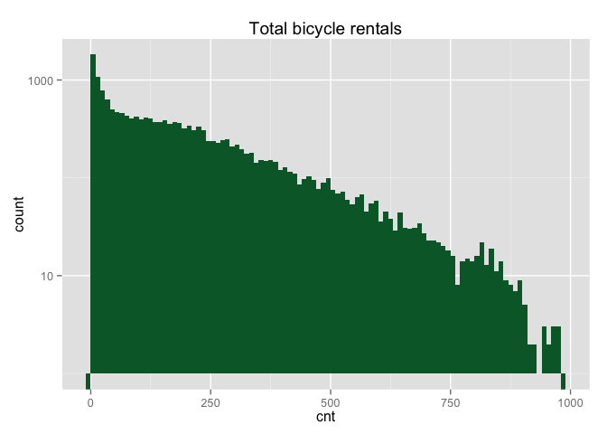

The bicycle rental frequencies seem to progressively decline for higher counts. I wonder how the frequencies will vary by season and weather conditions.

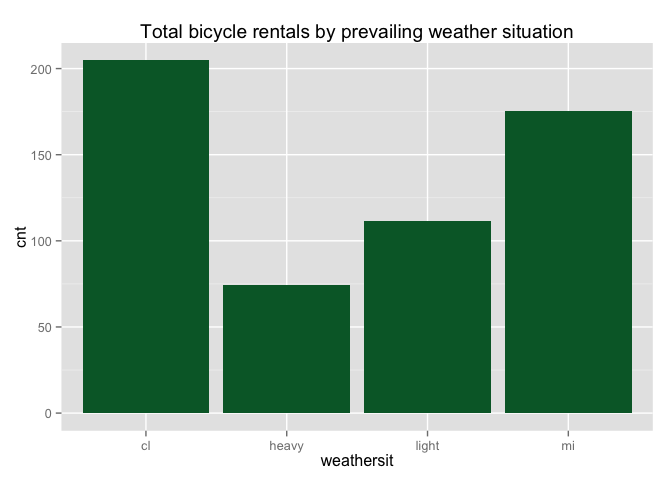

As is intuitive, we see that bicycle rentals are highest when the weather is clear, next highest when the weather is just misty, a few brave souls renting bicycles when there is light precipitation and least when there is heavy precipitation.

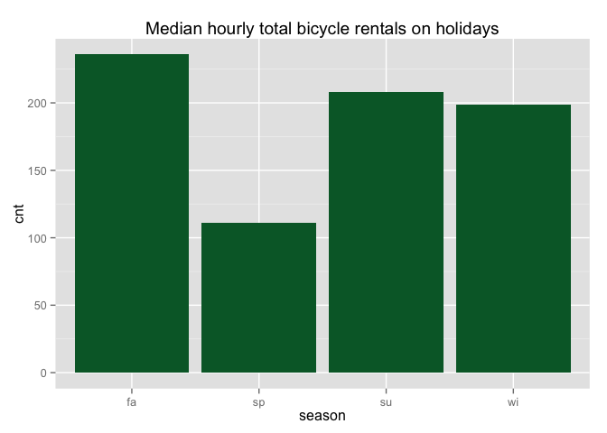

I cannot fathom the reason for this, but it looks like bicycle rentals are highest in the fall, next highest in summer, third in winter and lowest in spring.

Next, I subset-ed the data into two groups - one subset for holidays and one subset for working days. Here are the summaries of the bicycle rental numbers for the respective subsets:

```
##    Min. 1st Qu.  Median    Mean 3rd Qu.    Max.
##     1.0    40.0   144.0   190.4   281.5   977.0
```

```
##    Min. 1st Qu.  Median    Mean 3rd Qu.    Max.
##    1.00   28.75   97.00  156.90  253.20  712.00
```

From the preceding stats, we see that, all else set aside, bicycle rental numbers are higher on working days than on holidays - indicating that bicycle rentals may not be for recreational use.

Next, let’s explore how bicycle rentals stack up by day of the week.

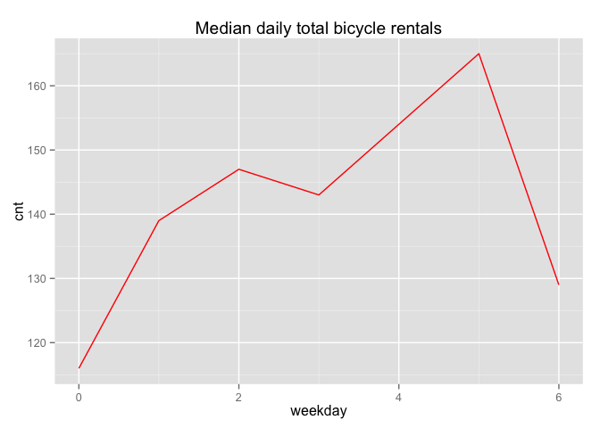

From the preceding plot, we see that the busiest day for bicycle rentals is Friday, and the least busy day is Sunday. Rental numbers climb up through the work week and then fall off on the weekend.

Let’s now look at how bicycle rental numbers stack up by hour of the day.

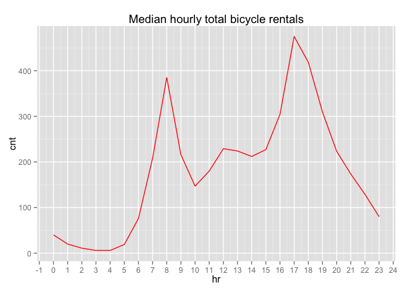

We see that bicycle rentals peak at 8:00am and 5:00pm and drop off on either side, suggesting that the peaks may be driven up by people using bicycles to get to and from work.

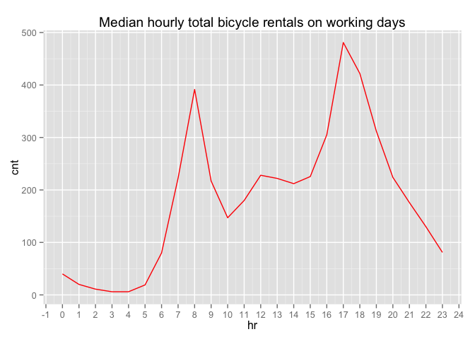

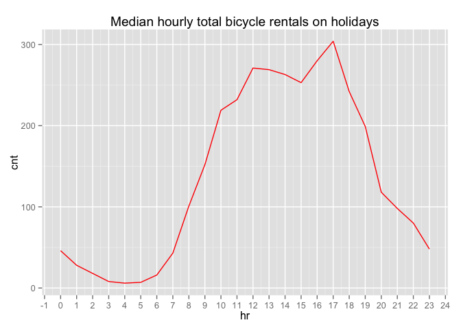

The preceding two plots are of bicycle rentals by the hour on working days and by the hour on holidays. While the plot for holidays shows higher numbers during the middle portion of the day, the plot for hourly rentals on working days is shockingly similar to the plot for the overall dataset - further reinforcing our belief that most bicycle rentals are made by people getting to-and-from work/school.

Let us now see how the numbers of casual and registered renters vary by the day of the week.

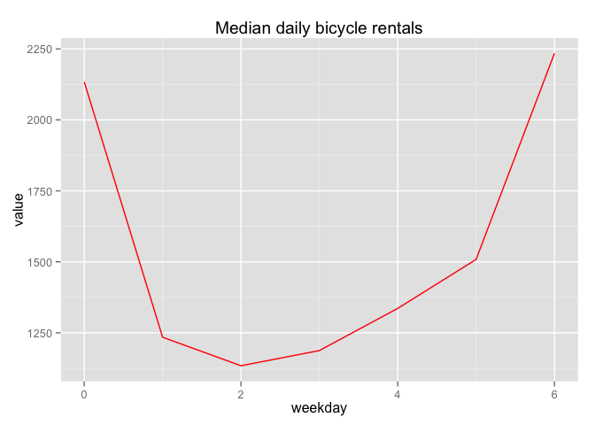

Let us now see how the numbers of casual and registered renters vary by hour of the day.

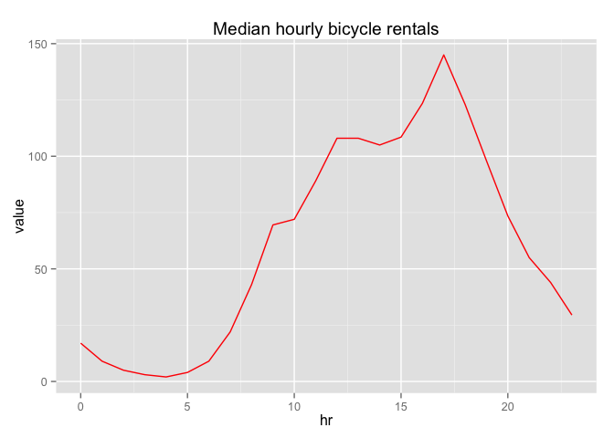

# Univariate analysis

The variables *weathersit*, *season*, *holiday* and *workingday* are categorical variables.  
**weathersit** has four states that I have simplified into: *clear*, *misty*, *light_precipi*(light rain/snow) and *heavy_precipi*(heavy rain/sleet/snow).  
**season** has four states: *spring*, *summer*, *fall* and *winter*.  
**holiday** and **workingday** are categorical variables that have binary values and orthogonal with each other in each observation.  
Other observations:  
1) Most bicycle rentals are made by registered customers than casual customers.  
2) More bicycle rentals are made by people that are commuting to their jobs/schools than recreational customers.  
3)Bicycle rentals are higher in dry weather than wet weather.

*What other features in the dataset do you think will help support your investigation into your feature(s) of interest?*  
We need to analyse some more to build a prediction model with higher confidence.  
I suspect windspeed, humidity and temperature will play a role in predicting bicycle rentals, but we shall see.

# Bivariate plots section

From the univariate analyses performed so far, I have seen that some features tend to correlate with each other. For example, average temperatures and precipitation seem to correlate with the season in a broader sense; these variables also seem to correlate with the weather situation in a much more specific sense.

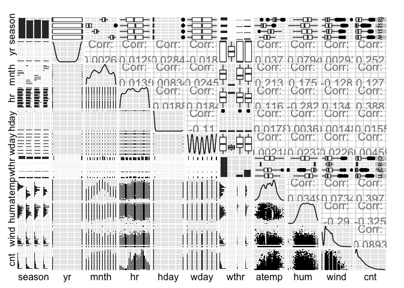

A quick look at the correlation data shows that bicycle rentals are mostly influenced by the feeling temperature and hour of the day.  
I will now explore some scatter plots involving total bicyle rentals together with normalized daily feeling temperatures, humidity and windspeed.

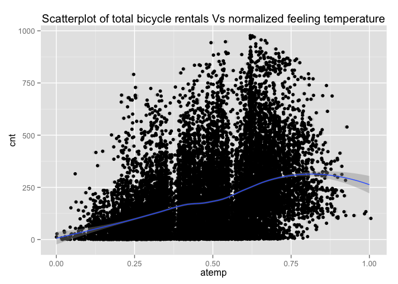

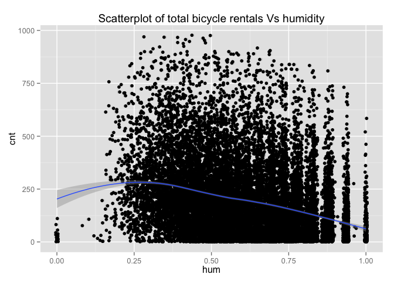

From the preceding plots, we see that most bicycle rentals occur when the normalized humidity is between 0.30-0.80.Taking a closer look at the rental number distributions between normalized humidities of 0.75-1.0, we see that there are certain “pockets” of distributions. At this point, it is not entirely clear what might be causing these distributions. It may be because certain values of normalized humidity never occur.

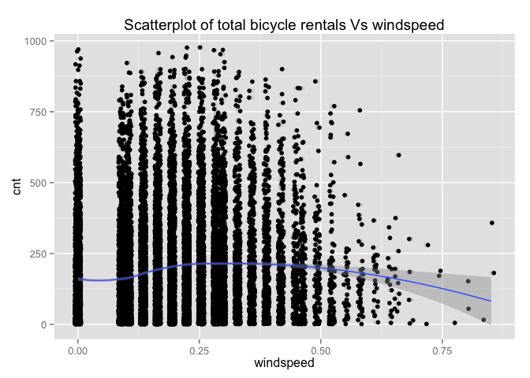

From the preceding plots, we see that bicycle rentals are pretty steady at lower windspeeds, dropping off at higher windspeeds.

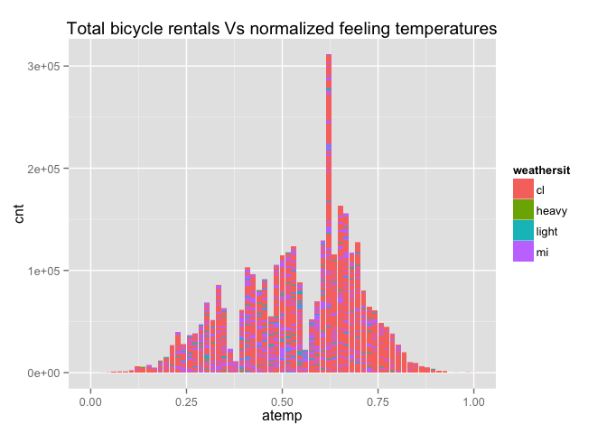

From the preceding plot, we see that bicycle rentals mostly happen in “moderate” feeling temperature. We see that clear weather rentals occur across the spectrum of feeling temperature. We also see that bicycle rentals in misty and light precipitation weather situations happen in a much narrower band of temperature. A peak stands out at a normalized feeling temperature of about 0.63, and we see that the rentals spike in clear, light precipitation and misty weather. Of course, very few rentals occur during periods of heavy precipitation.

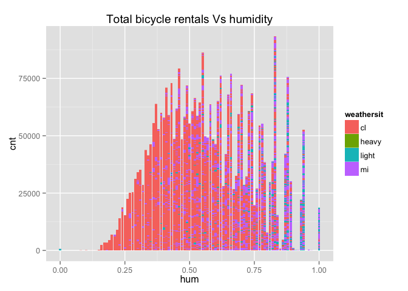

From the preceding plot, we see that most of the humidity range is dominated by clear weather and this is where a bulk of bicycle rentals take place. We do see a few peaks towards the higher end of the humidity spectrum, and this quartile seems to be dominated by misty weather for the most part and precipitative weather to a lesser extent.

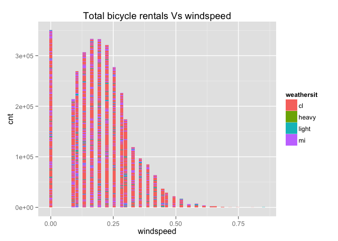

From the preceding plot, we see that most of the bicycle rentals happen in the first two quartiles of normalized windspeed. Rentals are highest when the normalized windspeed is 0, in fact. Beyond a normalized windspeed of 0.30, however, bicycle rentals fall away steadily and are almost non-exixtent in very windy weather. Most of the visible spectrum is dominated by clear weather.  
In fact, most of the bicycle rentals happen in clear weather, as shown by the summary below.

```
##       Min. 1st Qu. Median   Mean 3rd Qu. Max.
## cl       1    46.0    159 204.90   304.0  977
## heavy   23    29.5     36  74.33   100.0  164
## light    1    21.0     63 111.60   152.5  891
## mi       1    40.0    133 175.20   257.0  957
```

Let’s also look at a summary of bicycle rentals by season.

```
##    Min. 1st Qu. Median  Mean 3rd Qu. Max.
## fa    1      68  199.0 236.0     345  977
## sp    1      23   76.0 111.1     158  801
## su    1      46  165.0 208.3     311  957
## wi    1      46  155.5 198.9     295  967
```

From the above summary, it looks like bicycle rentals are high in the fall and summer and taper off in the winter and spring.  
Let’s now look at the number of casual bicycle rentals per season.

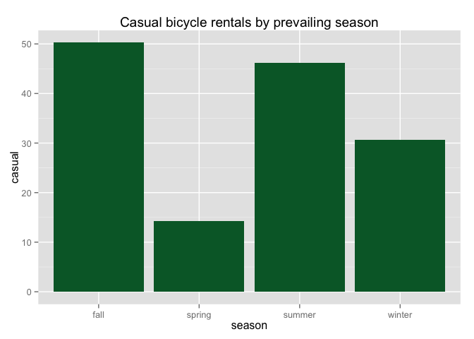

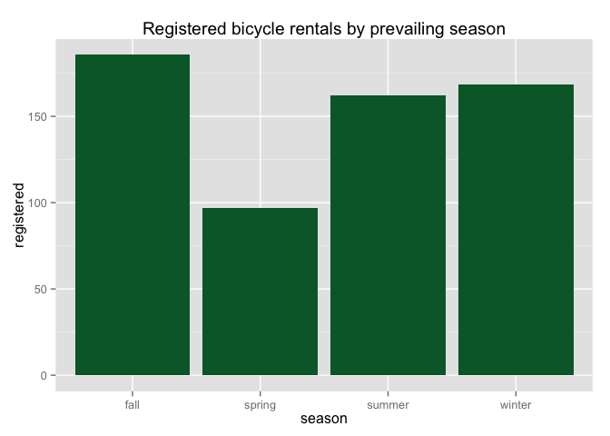

Though the number of registered riders using the service is consistently higher than the number of casual renters, we see that the general trends remain the same. Registered users seem to be a little more loyal than casual users, in that the winter ridership is about the same as the summer ridership - whereas it is much lower in the case of casual users.  
We have already seen that average feeling temperatures and hour of the day are the main influencers of bicycle rentals. Let’s look at how different weather conditions vary with the categorical variables.  
We already have a feel for how feeling temperatures are connected with weather conditions. We will see how average feeling temperatures vary by season.

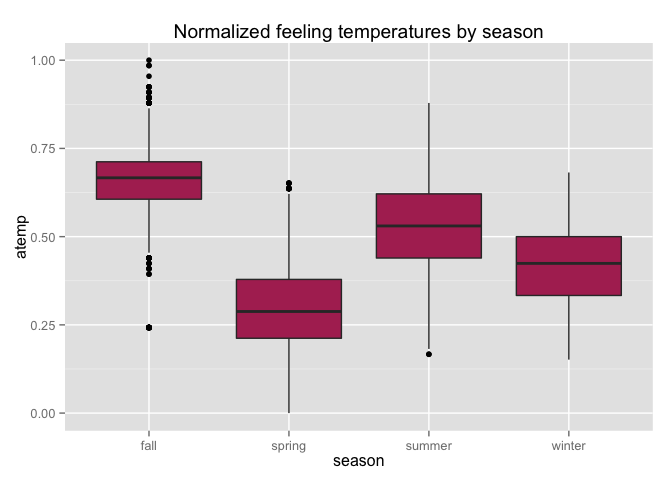

```
##      Min. 1st Qu. Median   Mean 3rd Qu.   Max.
## fa 0.2424  0.6061 0.6667 0.6560  0.7121 1.0000
## sp 0.0000  0.2121 0.2879 0.2981  0.3788 0.6515
## su 0.1667  0.4394 0.5303 0.5205  0.6212 0.8788
## wi 0.1515  0.3333 0.4242 0.4157  0.5000 0.6818
```

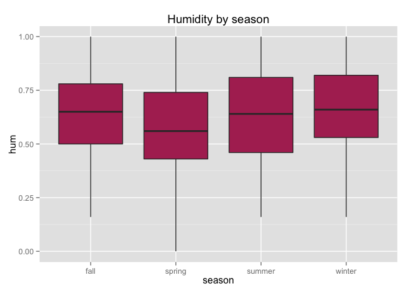

```
##    Min. 1st Qu. Median   Mean 3rd Qu. Max.
## fa 0.16    0.50   0.65 0.6332    0.78    1
## sp 0.00    0.43   0.56 0.5813    0.74    1
## su 0.16    0.46   0.64 0.6270    0.81    1
## wi 0.16    0.53   0.66 0.6671    0.82    1
```

Humidity values are highest in winter, about the same in fall and summer, and lowest in spring. This is contrary to the trends we see for bicycle rentals. This reinforces our finding that humidity is not a great predictor of bicycle rentals. Let us take a look at how windspeeds influence bicycle rentals.

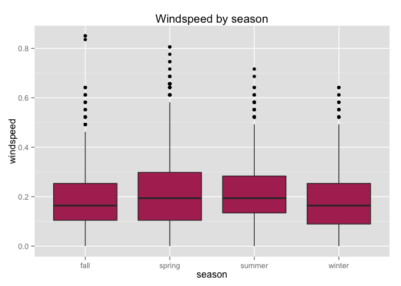

```
##    Min. 1st Qu. Median   Mean 3rd Qu.   Max.
## fa    0  0.1045 0.1642 0.1716  0.2537 0.8507
## sp    0  0.1045 0.1940 0.2151  0.2985 0.8060
## su    0  0.1343 0.1940 0.2034  0.2836 0.7164
## wi    0  0.0896 0.1642 0.1708  0.2537 0.6418
```

Windspeeds are highest in spring and summer, and about the same in fall and winter. This trend is contrary to the bicycle rental trends.  
From the preceding boxplots, we see that only average feeling temperature trends mimic that of bicycle rentals.

```
##
## Call:
## lm(formula = cnt ~ registered, data = df_master)
##
## Residuals:
##      Min       1Q   Median       3Q      Max
## -118.031  -16.264   -9.957    4.730  304.223
##
## Coefficients:
##              Estimate Std. Error t value Pr(>|t|)
## (Intercept) 10.296458   0.459718    22.4   <2e-16 ***
## registered   1.165032   0.002131   546.8   <2e-16 ***
## ---
## Signif. codes:  0 '***' 0.001 '**' 0.01 '*' 0.05 '.' 0.1 ' ' 1
##
## Residual standard error: 42.51 on 17377 degrees of freedom
## Multiple R-squared:  0.9451, Adjusted R-squared:  0.9451
## F-statistic: 2.99e+05 on 1 and 17377 DF,  p-value: < 2.2e-16
```

```
##
## Call:
## lm(formula = cnt ~ temp, data = df_master)
##
## Residuals:
##     Min      1Q  Median      3Q     Max
## -291.37 -110.23  -32.86   76.77  744.76
##
## Coefficients:
##             Estimate Std. Error t value Pr(>|t|)
## (Intercept)  -0.0356     3.4827   -0.01    0.992
## temp        381.2949     6.5344   58.35   <2e-16 ***
## ---
## Signif. codes:  0 '***' 0.001 '**' 0.01 '*' 0.05 '.' 0.1 ' ' 1
##
## Residual standard error: 165.9 on 17377 degrees of freedom
## Multiple R-squared:  0.1638, Adjusted R-squared:  0.1638
## F-statistic:  3405 on 1 and 17377 DF,  p-value: < 2.2e-16
```

```
##
## Call:
## lm(formula = cnt ~ hr, data = df_master)
##
## Residuals:
##     Min      1Q  Median      3Q     Max
## -305.86 -102.80  -45.85   66.50  730.16
##
## Coefficients:
##             Estimate Std. Error t value Pr(>|t|)
## (Intercept)  70.0952     2.4616   28.48   <2e-16 ***
## hr           10.3378     0.1829   56.52   <2e-16 ***
## ---
## Signif. codes:  0 '***' 0.001 '**' 0.01 '*' 0.05 '.' 0.1 ' ' 1
##
## Residual standard error: 166.7 on 17377 degrees of freedom
## Multiple R-squared:  0.1553, Adjusted R-squared:  0.1552
## F-statistic:  3195 on 1 and 17377 DF,  p-value: < 2.2e-16
```

```
##
## Call:
## lm(formula = cnt ~ season, data = df_master)
##
## Residuals:
##     Min      1Q  Median      3Q     Max
## -235.02 -118.87  -39.11   85.89  768.13
##
## Coefficients:
##              Estimate Std. Error t value Pr(>|t|)
## (Intercept)   236.016      2.615  90.268  < 2e-16 ***
## seasonspring -124.902      3.753 -33.284  < 2e-16 ***
## seasonsummer  -27.672      3.716  -7.447 9.99e-14 ***
## seasonwinter  -37.147      3.755  -9.893  < 2e-16 ***
## ---
## Signif. codes:  0 '***' 0.001 '**' 0.01 '*' 0.05 '.' 0.1 ' ' 1
##
## Residual standard error: 175.3 on 17375 degrees of freedom
## Multiple R-squared:  0.06599,    Adjusted R-squared:  0.06583
## F-statistic: 409.2 on 3 and 17375 DF,  p-value: < 2.2e-16
```

# Bivariate analysis

*Did you observe any interesting relationships between the other features (not the main feature(s) of interest)?*  
I looked at the relationships between some more features in the dataset. I see that there is a moderate relationship between humidity and the prevailing weather situation of the day. I see that there is a strong relationship between the normalized temperature on a given day and the corresponding season.

*What was the strongest relationship you found?*  
The strongest relationship I found was between the total bicycle rental numbers and number of registered renters. The other strong relationship I found was between the prevailing daily normalized temperatures and the season.

# Multivariate Plots Section

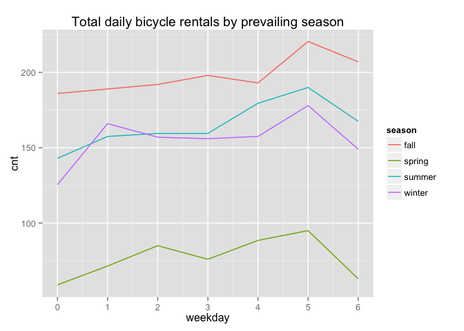

We see that daily median ridership for each day of the week is lowest in spring and highest in the fall seasons. The daily medians numbers follow a closer trend early in the week in summer and winter.

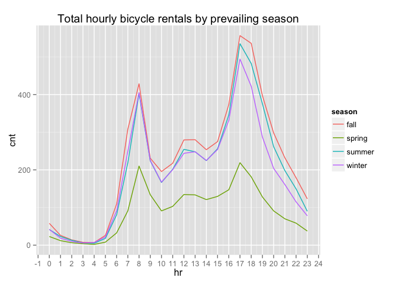

Looking at the median hourly ridership numbers, we see that the numbers are lowest in spring, while they follow a closer trend in the other seasons. The numbers are pretty much the same in the early hours of the day(owing to the extremely low rentals). For hourly numbers in summer, fall and winter, we see they closely converge at around 9:00am and between 4:00pm and 5:00pm - showing that these are primarily planned rentals.

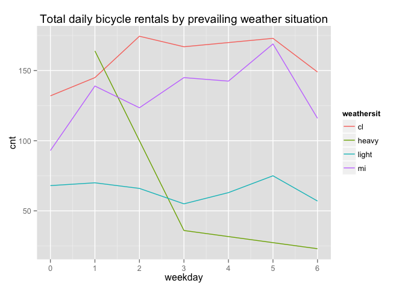

The preceding plot shows the median daily bicycle rentals depending on the prevailing weather situation of the day. Heavy precipitation seems to not deter bicycle renter on Mondays and Tuesdays, while on other days, heavy precipitation ensures low ridership. As predictable, highest bicyle ridership happens on clear days, followed by mild weather days and then on days that see light precipitation.

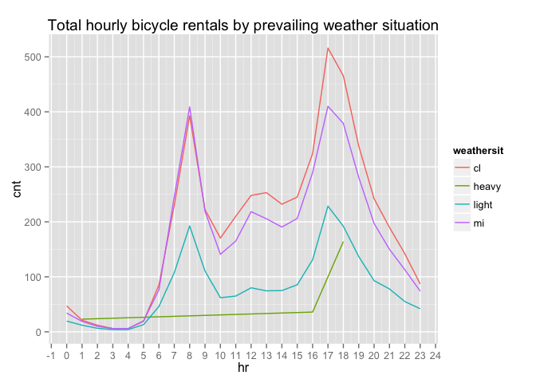

These plots show how the hourly and daily bicycle rentals depending on the weather situation and the seasons. I wonder how these trends would vary with temperature, humidity and windspeed factors too.

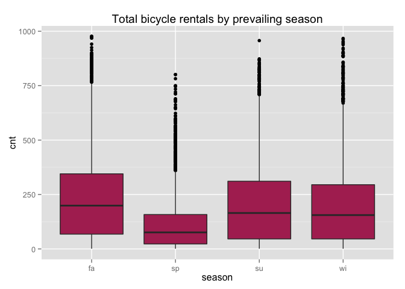

```
##    Min. 1st Qu. Median  Mean 3rd Qu. Max.
## fa    1      68  199.0 236.0     345  977
## sp    1      23   76.0 111.1     158  801
## su    1      46  165.0 208.3     311  957
## wi    1      46  155.5 198.9     295  967
```

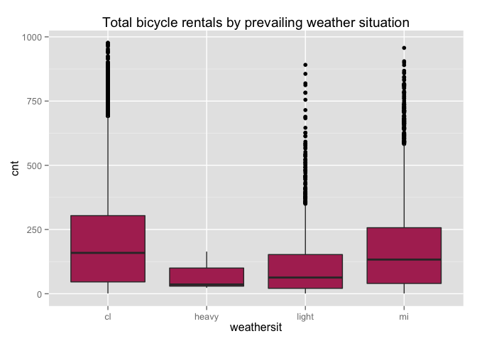

```
##       Min. 1st Qu. Median   Mean 3rd Qu. Max.
## cl       1    46.0    159 204.90   304.0  977
## heavy   23    29.5     36  74.33   100.0  164
## light    1    21.0     63 111.60   152.5  891
## mi       1    40.0    133 175.20   257.0  957
```

The preceding boxplots reinforce our findings that bicycle rentals are lowest in spring, followed by winter and summer and highest in the fall. Looking at the stats for each quartile, we see that the trends are close for the other three seasons except spring. We also see that periods of precipitation show lower bicycle rentals in the initial quartiles than for higher quartiles. *The main anomaly we see is that for the first quartile, bicycle rentals are higher in periods of heavy precipitation than in periods of light precipitation.*Towards the higher quartiles, though, we see that bicycle rentals in non-precipitative weather dominates.  
Since bicycle rentals are dominated by registered users, and because we saw from prior analysis that bicycle rental trends closely match office/school-going patters, I thought that it might be a good idea to explore the trends among casual users. I added a new column to the dataframe to represent the ratio of casual user rentals to the total renters.

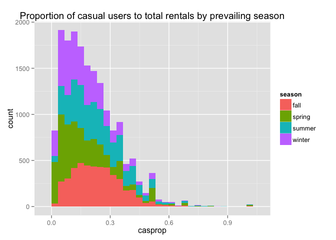

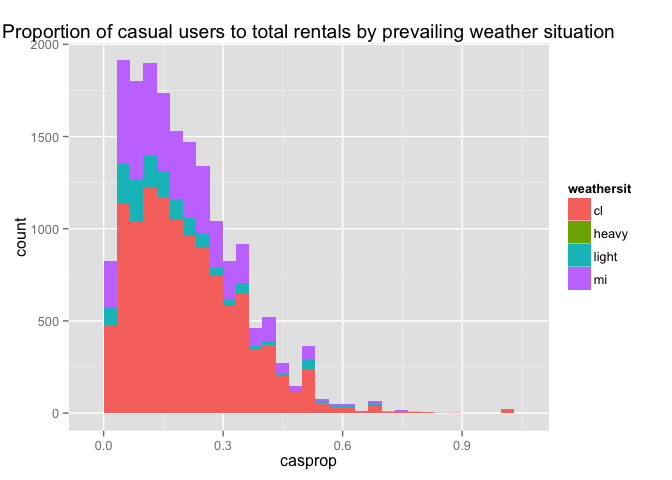

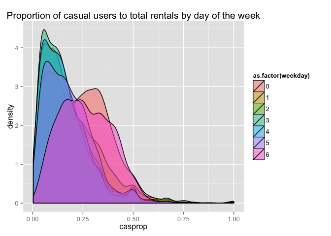

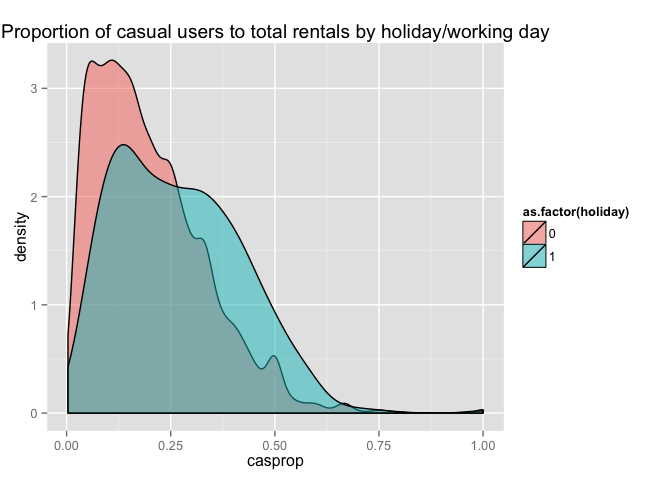